# Basic survival analysis

## Introduction

In survival data, we not only know if whether someone had the event, we also have the **time to the event**. With survival data, we often deal with **censoring**. Censoring means that we don’t know *when* the event occurred. For some events, we only know that it occurred *after* a certain time (this is called **right censoring**).

With this type of data, we may want to answer the following questions:

- What is the median survival time?
- What proportion survived after 1 year? After 2 years?
- Is the survival different between different groups?

In this tutorial, we will learn the basics of analyzing survival data in R. This will not be comprehensive! The goal is to get a taste of implementing some common survival analysis tasks in R.

## Creating a time to event variable

To analyze survival data in R, we can use the `survival` package. We will also use the `dplyr` package in some of the code.

```r
# install.packages("survival")

library(survival)
library(dplyr)
```

For this tutorial, we will use the `lung` dataset, which is automatically loaded through the survival package. The data contain subjects with advanced lung cancer from the North Central Cancer Treatment Group. The *event* of interest is death.

```r
head(lung)
```

```
##   inst time status age sex ph.ecog ph.karno pat.karno meal.cal wt.loss
## 1    3  306      2  74   1       1       90       100     1175      NA
## 2    3  455      2  68   1       0       90        90     1225      15
## 3    3 1010      1  56   1       0       90        90       NA      15
## 4    5  210      2  57   1       1       90        60     1150      11
## 5    1  883      2  60   1       0      100        90       NA       0
## 6   12 1022      1  74   1       1       50        80      513       0
```

This dataset has several columns, but we will focus only on time, status, and sex for this tutorial:

```r
lung %>%
  select(time, status, sex) %>%
  head()
```

```
##   time status sex
## 1  306      2   1
## 2  455      2   1
## 3 1010      1   1
## 4  210      2   1
## 5  883      2   1
## 6 1022      1   1
```

Here is the definition of these variables:

- **Status**: 1-censored (e.g. did not have the event) or 2-dead
- **Time**: Time to event or censoring
- **Sex**: 1-male or 2-female

For those that are censored, we assume that either the study ended or they were no longer observed after the censoring date. We know that they had the event (e.g. died) at some point, but we don’t know when. We only know it happened after a specific time.

To analyze survival data using the `survival` package, we want to make sure there are two key columns: (1) a time column, and (2) a status column. The status column must be coded as 0s or 1s, where 0 is for those that are censored and 1 is for those that were not (e.g. had the event). As a first step, we convert the status column in our dataset (which consists of 1s and 2s) to 0s and 1s.

```r
# use the mutate function to change a column of the datset
lung_new <- lung %>%
  mutate(status = ifelse(status == 2, 1, 0))
```

Our next step is to create a time-to-event column. This column will encode the information in both the time and status columns. We can use the `Surv()` function from the `survival` package to create this column. The first argument of this function is the time variable, and the second argument is the status variable.

```r
# use mutate function to create time-to-event column
lung_new <- lung_new %>%
  mutate(tte = Surv(time, status))
```

Let’s take a peak at what this new variable looks like:

```r
lung_new %>%
  select(time, status, tte) %>%
  head()
```

```
##   time status   tte
## 1  306      1   306
## 2  455      1   455
## 3 1010      0 1010+
## 4  210      1   210
## 5  883      1   883
## 6 1022      0 1022+
```

For those that had the event (status = 1), we can see the tte column shows of the time of the event. For those that were censored, we can see that the tte column shows the last observation time with a + symbol, indicating that the had the event *after* that timepoint.

## Creating survival plots

After creating the survival variable, we may want to create a Kaplan-Meier survival plot. This plot shows the estimated proportion who are still alive at different timepoints. To create this plot, we first can use the `survfit()` function. The function takes in two arguments The first is the formula which looks like `tte ~ -1`. Before the tilde (~), we have tte, which is the time-to-event variable that we created. The -1 after the tilde here indicates that we want an overall Kaplan-Meier curve, not a stratified one. The second argument is the data.

```r
# first argument is the formula tte ~ -1
# second argument is the data
km <- survfit(tte ~ -1, data = lung_new)
```

Next, we can graph this plot using the `ggsurvplot()` function from the `survminer` package. We put in the survfit object as the argument.

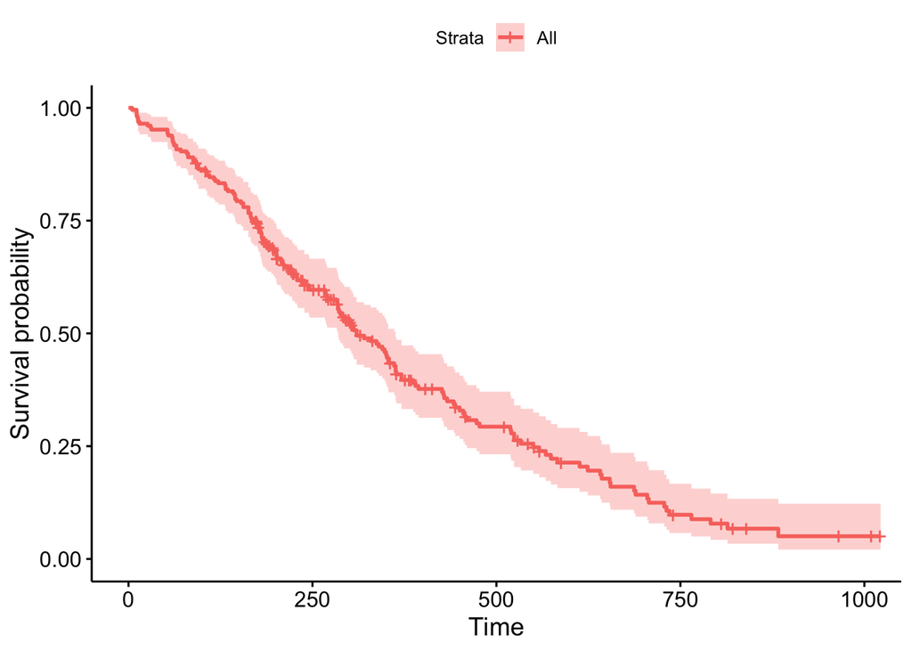

```r
# install.packages("survminer")

library(survminer)
ggsurvplot(km)
```

Now suppose that we want to graph the curve, stratified by sex. Within the `survfit()` function, we specify the formula `tte ~ sex`. Including sex after the tilde creates curves stratified by sex.

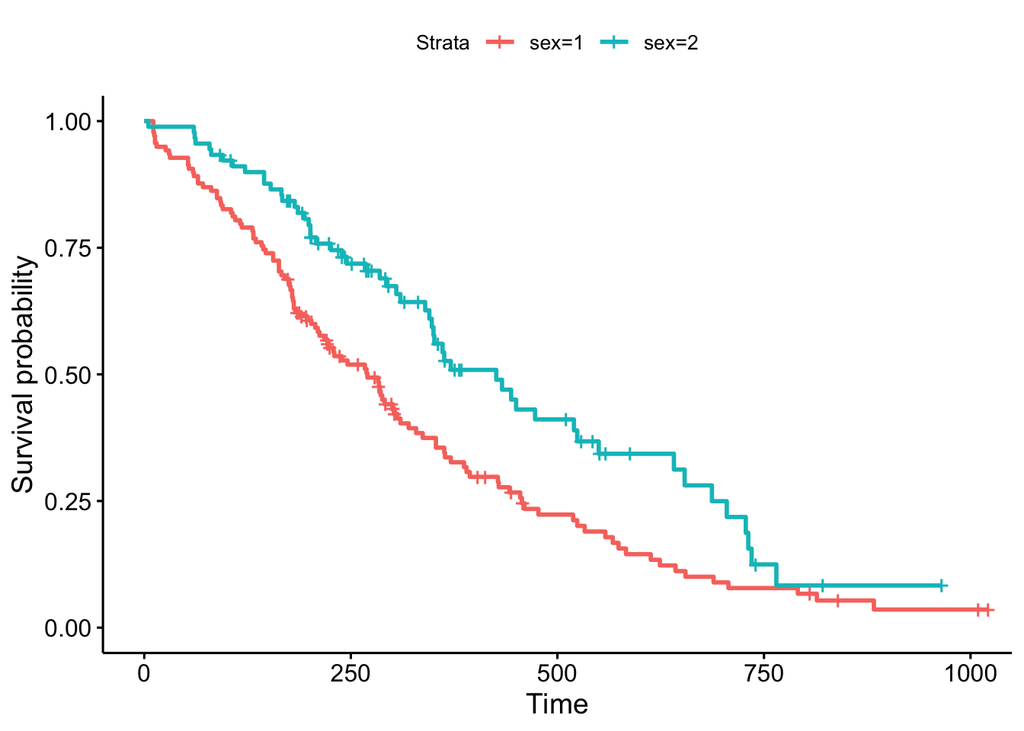

```r
# stratified Kaplan-Meier curve
km_sex <- survfit(tte ~ sex, data = lung_new)

# graph stratified curves
ggsurvplot(km_sex)
```

This shows the curves separated by males and females. The curves show that females generally have better survival than males throughout the study.

## Log rank test

In the previous section, we saw that the females had a noticeably different Kaplan-Meier survival curve compared to males. We can perform a hypothesis test to check these curves are *significantly* different. The hypothesis test to do this is called the **log rank test**.

The null hypothesis of the log rank test is that the survival curves are the same. Setting a significance threshold of 0.05, if we observe a p-value less than that, then we reject the null hypothesis (i.e. find evidence of significant differences between the two curves).

To perform the log rank test in R, we can use the `survdiff()` function. The structure of this function is similar to `survfit()` function. We first specify the formula, in this case `tte ~ sex`. This tells the function to test if the time-to-event survival variable is significantly different by sex. The second argument is the data.

```r
survdiff(tte ~ sex, data = lung_new)
```

```
## Call:
## survdiff(formula = tte ~ sex, data = lung_new)
##
##         N Observed Expected (O-E)^2/E (O-E)^2/V
## sex=1 138      112     91.6      4.55      10.3
## sex=2  90       53     73.4      5.68      10.3
##
##  Chisq= 10.3  on 1 degrees of freedom, p= 0.001
```

With $p=0.001$, we find evidence that the two curves are significantly different.

## Exercise

Using the lung dataset, graph separate Kaplan-Meier curves for participants with different values of ph.ecog. (Note: ph.ecog is the ECOG performance score as rated by the physician. Ranked 0-3, with increasing severity.)

Perform a test to see if the survival curves are significantly different.

*[Click here](https://jpspeng.github.io/crisp_notes/) to go back to the CRISP R notes homepage.*